# Project: Investigate a Dataset (Medical Appointments No Shows)

# 2.What is the gender distribution for patients who showed up and patients who didn't?

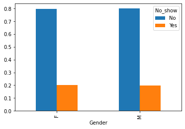

```python
# Checking the distribution between genders who showed up and didn't
data.groupby("Gender")["No_show"].value_counts(normalize=True).unstack().plot(kind="bar");
```

```python
data.groupby("Gender")["No_show"].value_counts(normalize=True).unstack()
```

| No_show Gender | No | Yes |
| --- | --- | --- |
| F | 0.796851 | 0.203149 |
| M | 0.800321 | 0.199679 |

The percentage of show up and no show in male and female are slightly little.

# 3.Does Neighbourhood affect patients?

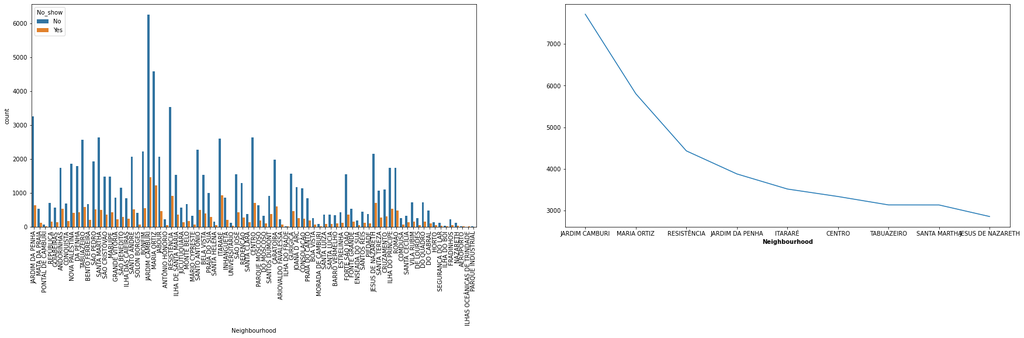

```python
plt.figure(figsize=(30,7))
plt.subplot(1,2,1)
sns.countplot(data=data, x = "Neighbourhood", hue = "No_show")
plt.xticks(rotation=90);

plt.subplot(1,2,2)
pl = data["Neighbourhood"].value_counts()[0: 9]
plt.xlabel("Neighbourhood", weight = 'bold')
plt.plot(pl);
```

This shows that popular neighborhood like JARDIM CAMBURI have more patients attending their appointment. This could be due to the service quality being provide by the hospitals in the neighborhood or sercurity reasons.

# 4.What factors are important to know in order to predict if a patient will show up for their scheduled appointment?

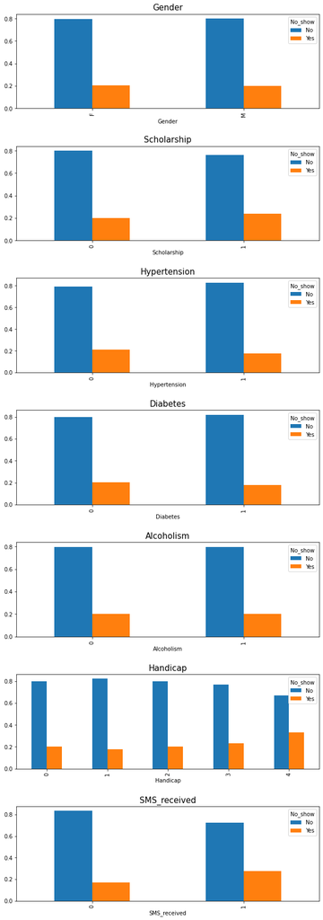

```python
# Getting the proportion of the data to check changes in the categories
factors = ['Gender', 'Scholarship', 'Hypertension', 'Diabetes', 'Alcoholism', 'Handicap', 'SMS_received']
fig, ax = plt.subplots(7, figsize = (10, 30))
fig.subplots_adjust(hspace=0.4)
for i,factor in enumerate(factors):
    data.groupby([factor])["No_show"].value_counts(normalize=True).unstack().plot(ax = ax[i], kind = 'bar')
    ax[i].set_title(factor, size = 15, pad = 7)
```

# An Overview;

Gender: The percentage of show up and no show in male and female are the same.

Alcoholism: There seems to be an equal percentage distribution between those who show up for their appointment and those who don't.

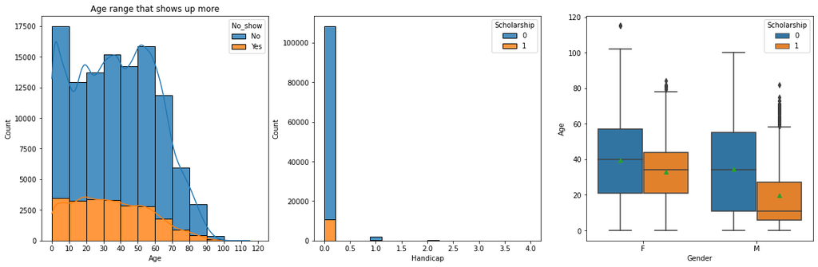

```python
plt.figure(figsize=(20,6))
plt.subplot(131)
sns.histplot(data=data, x ="Age", hue = "No_show", multiple = "stack",bins=np.arange(0,130,10), alpha =0.8, kde=True)
plt.xticks(np.arange(0,130,10))
plt.xlabel("Age")
plt.title("Age range that shows up more")

plt.subplot(132)
sns.histplot(data=data,x="Handicap", hue = "Scholarship", multiple = "stack", alpha =0.8)
plt.subplot(133)
sns.boxplot(y="Age",x = "Gender", hue = "Scholarship", data=data, showmeans=True);
```

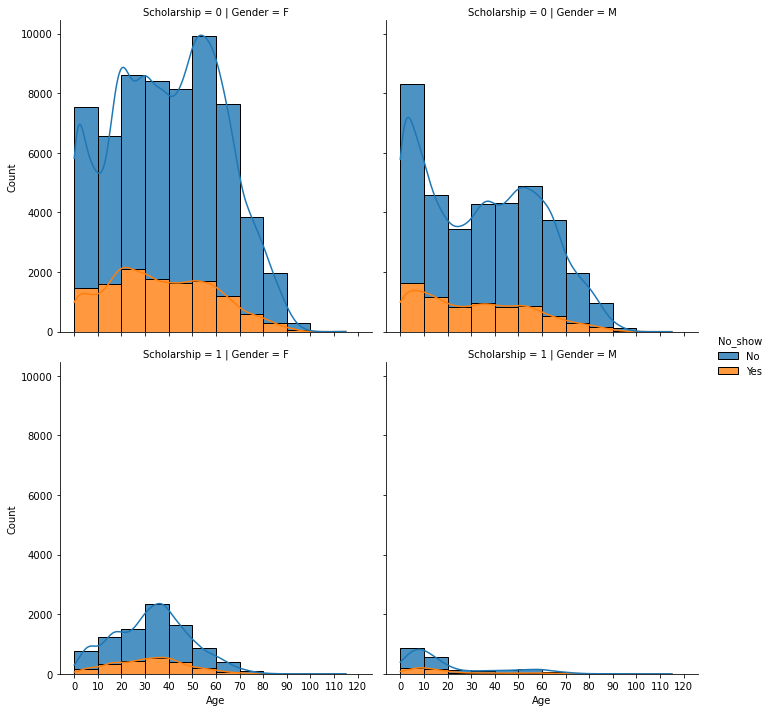

```python
sns.displot(data=data,x="Age", hue = "No_show", multiple = "stack", bins=np.arange(0,130,10), alpha =0.8, kde=True,col = "Gender", row="Scholarship")
plt.xticks(np.arange(0,130,10));
```

# 5. What days are being scheduled the most?

```python
# Checking to view the days of the week with higher schedules
data["Sch_for_week"].value_counts()
```

```
Tuesday      26168
Wednesday    24262
Monday       23084
Friday       18915
Thursday     18073
Saturday        24
Name: Sch_for_week, dtype: int64
```

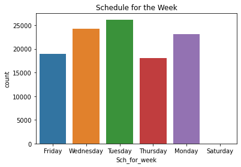

```python
# Graphical representation
sns.countplot(data=data, x = "Sch_for_week")
plt.title("Schedule for the Week");
```

# 6. Does age affect the number of attendance?

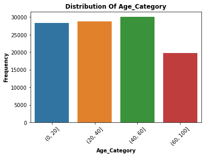

```python
# Checking the age categories
count_plot(data,"Age_category")
plt.xticks(rotation=45);
```

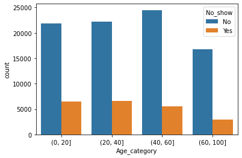

```python
# CChecking the age category that show up more
sns.countplot(data=data,x="Age_category",hue="No_show");
```

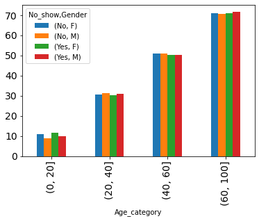

```python
# Checking the age categories of genders who show up more
a = ["No_show", "Gender"]
data.pivot_table(index = "Age_category", columns = a, values ="Age").plot(kind="bar",fontsize = 14);
```

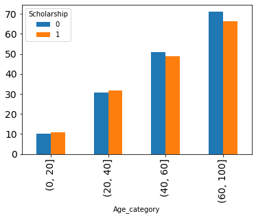

```python
a = ["Scholarship"]
data.pivot_table(index = "Age_category", columns = a, values ="Age").plot(kind="bar",fontsize = 14);
```

## Conclusions

The dataset had some wrong spellings in the column header, I corrected them and also drop some rows and some unwanted columns which were not needed for my analysis, I also compared the variables in the dataset using the "No_show" column as my dependent variable and here are my findings;

Popular neighborhood like JARDIM CAMBURI have more patients attending their appointment. This could be due to the service quality being provide by the hospitals in the neighborhood or sercurity reasons.This shows that neighborhood plays a role with patients meeting up with their appointments.

Most of the patients are not alcoholics.

To help increase the show-up rate, some things should be acted upon:

1.The shedule should also be spread out to saturday and Sunday, it maybe that the patients are busy during work days to show up.

from the patient which causes less turn out for their appointments, so paitents should be giving the choice to pick a hospital close to their neighborhood.

3.Granting and trying to encourage more males to register for the welfare program.

# Limitations

This dataset was useful to perform some ceratin extent, the data showed the various categories of illness, those that are on scholarship, their different ages, but didn't provide why the patients didn't show up to their appointment. The data wasn't categorised whether the appointment was an emergency or if it was a normal random check up, if this was stated we could have know why patients do show up or not, we would have had a better insights to thier reasons.